# FaceFake2 - Data Analysis

## Summary

Notably, only the attractiveness model successfully converged when random slopes for Relevance were added at the image level. While it is generally recommended to specify the maximal random-effects structure justified by the design to improve generalizability Bar et al., 2023 , maintaining consistency across models is also important to enable meaningful comparisons, hence the latter was prioritised.

The **effect of image condition** (AI-generated vs. photo) differed significantly between females and males.

For males, the only significant effect of condition was that irrelevant images labeled as AI-generated were rated lower in beauty.

## Data Preparation

```r
library(tidyverse)
library(easystats)
library(patchwork)
library(ggside)

results_table <- function(model, effects="fixed", filter=NULL) {
  if("marginaleffects" %in% class(model)) {
    model |>
      parameters::parameters() |>
      as.data.frame() |>
      select(-Parameter, -SE, -S, z=Statistic) |>
      insight::format_table() |>
      parameters::display()
  } else {
    display(parameters::parameters(model, effects=effects, keep=filter))
  }
}
```

```r
df <- read.csv("../data/data_participants.csv")
dftask <- read.csv("../data/data_task.csv") |>
  mutate(Condition = fct_relevel(Condition, "Photograph", "AI-Generated"),
         Relevance = fct_relevel(Relevance, "Relevant", "Irrelevant"),
         Attractiveness = Attractiveness / 6,
         Beauty = Beauty / 6,
         Trustworthiness = Trustworthiness / 6,
         Realness = Realness / 6 + 0.5,
         RealnessBelief = ifelse(Realness > 0.5, 1, 0),
         Gender = fct_relevel(Gender, "Male", "Female"))

dftask <- full_join(dftask,
                    select(df, Participant, starts_with("HEXACO"), -ends_with("_NR"), -ends_with("_R")),
                    by="Participant")
```

## Visualisation of Variables

**Attractiveness**

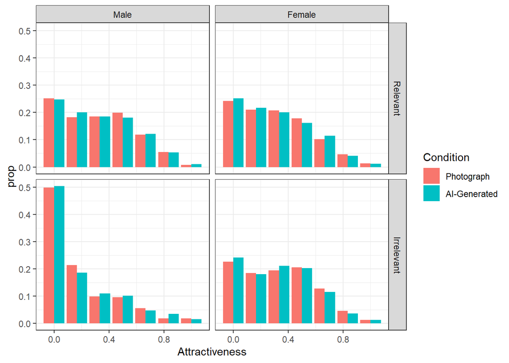

```r
dftask |>
  ggplot(aes(x=Attractiveness, fill=Condition)) +
  geom_bar(aes(y = after_stat(prop)), position="dodge") +
  facet_grid(Relevance~Gender) +
  theme_bw()
```

This model looks at the effect of Gender and Relevance on attractiveness scores, accounting for random variabilty due to participants and items (i.e., random effects).

Females did not rate faces significantly higher than males in attractiveness. However, both genders rated irrelevant images lower in attractiveness than relevant ones.

```r
m_a<- glmmTMB::glmmTMB(Attractiveness ~ Gender / Relevance +
                                       (Relevance | Participant) + (1|Stimulus),
                      data=dftask,
                      family=glmmTMB::ordbeta(),
                      control = glmmTMB::glmmTMBControl(parallel = 8))

results_table(m_a)
```

Fixed Effects

| Parameter | Coefficient | SE | 95% CI | z | p |
| --- | --- | --- | --- | --- | --- |
| (Intercept) | -0.72 | 0.13 | (-0.97, -0.46) | -5.50 | < .001 |
| Gender (Female) | 0.15 | 0.14 | (-0.13, 0.43) | 1.03 | 0.304 |
| Gender (Male) × RelevanceIrrelevant | -0.82 | 0.14 | (-1.08, -0.55) | -6.05 | < .001 |
| Gender (Female) × RelevanceIrrelevant | -0.29 | 0.08 | (-0.44, -0.13) | -3.61 | < .001 |

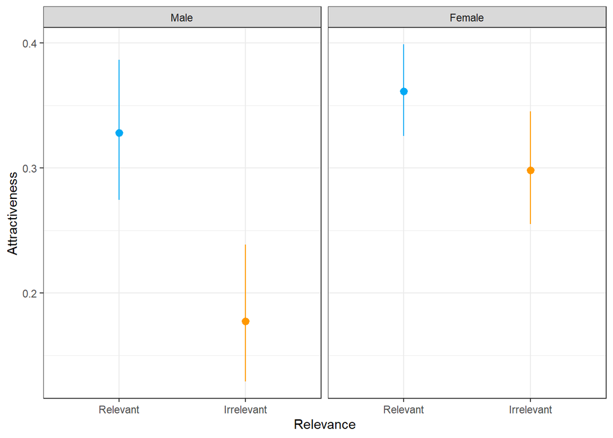

```r
estimate_relation(m_a) |>
  ggplot(aes(x=Relevance, y=Predicted)) +
  geom_pointrange(aes(ymin=CI_low, ymax=CI_high, color=Relevance), position=position_dodge(width=0.5)) +
  scale_color_manual(values=c("Relevant"="#03A9F4", "Irrelevant"="#FF9800"), guide = "none") +
  labs(y="Attractiveness") +
  facet_wrap(~Gender) +
  theme_bw()
```

**Beauty**

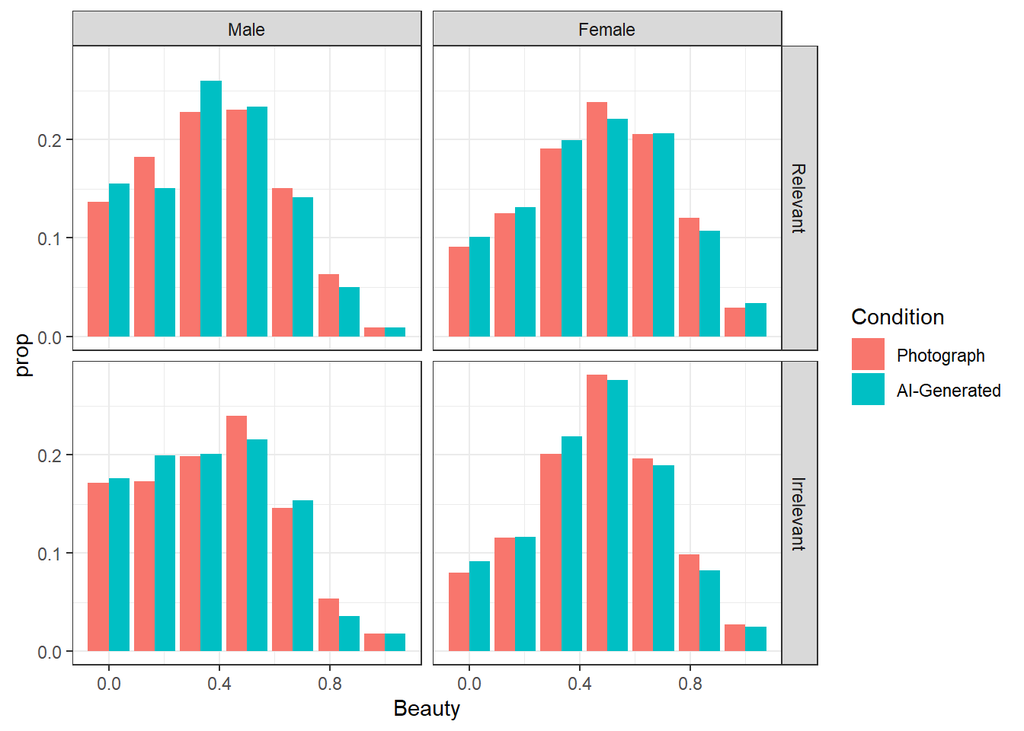

```r
dftask |>
  ggplot(aes(x=Beauty, fill=Condition)) +
  geom_bar(aes(y = after_stat(prop)), position="dodge") +
  facet_grid(Relevance~Gender) +
  theme_bw()
```

This model looks at the effect of Gender and Relevance on beauty scores, accounting for random variabilty due to participants and items (i.e., random effects).

Females rated faces significantly higher than males in beauty. Males rated irrelevant images as more beautiful than relevant ones, whilst females rated irrelevant images as less beautiful than relevent ones, both effects were significant.

```r
m_b<- glmmTMB::glmmTMB(Beauty ~ Gender / Relevance +
                                       (Relevance | Participant) + (1|Stimulus),
                      data=dftask,
                      family=glmmTMB::ordbeta(),
                      control = glmmTMB::glmmTMBControl(parallel = 8))

results_table(m_b)
```

Fixed Effects

| Parameter | Coefficient | SE | 95% CI | z | p |
| --- | --- | --- | --- | --- | --- |
| (Intercept) | -0.61 | 0.12 | (-0.84, -0.39) | -5.29 | < .001 |
| Gender (Female) | 0.57 | 0.12 | (0.32, 0.81) | 4.55 | < .001 |
| Gender (Male) × RelevanceIrrelevant | 0.23 | 0.07 | (0.09, 0.38) | 3.13 | 0.002 |
| Gender (Female) × RelevanceIrrelevant | -0.10 | 0.04 | (-0.19, -0.01) | -2.25 | 0.024 |

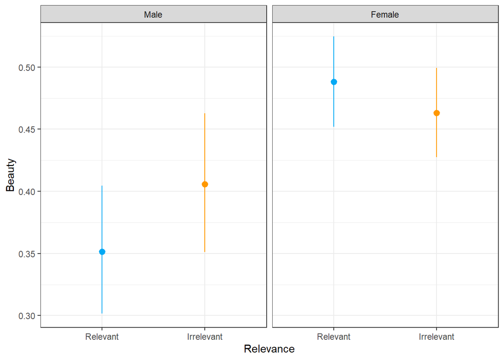

```r
estimate_relation(m_b) |>
  ggplot(aes(x=Relevance, y=Predicted)) +
  geom_pointrange(aes(ymin=CI_low, ymax=CI_high, color=Relevance), position=position_dodge(width=0.5)) +
  scale_color_manual(values=c("Relevant"="#03A9F4", "Irrelevant"="#FF9800"), guide = "none") +
  labs(y="Beauty") +
  facet_wrap(~Gender) +
  theme_bw()
```

**Trustworthiness**

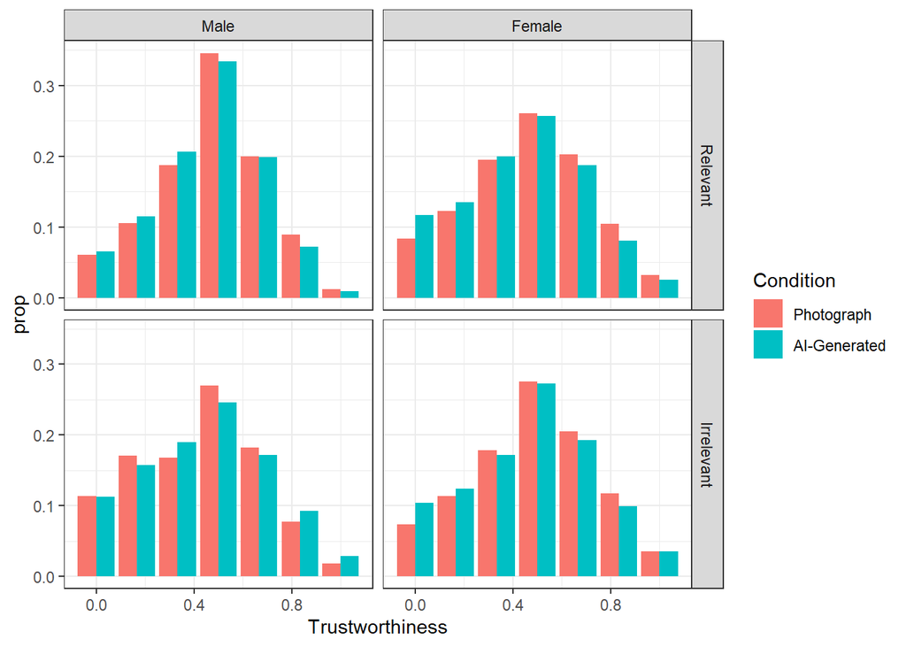

```r
dftask |>
  ggplot(aes(x=Trustworthiness, fill=Condition)) +
  geom_bar(aes(y = after_stat(prop)), position="dodge") +
  facet_grid(Relevance~Gender) +
  theme_bw()
```

This model looks at the effect of Gender and Relevance on trustworthiness scores, accounting for random variabilty due to participants and items (i.e., random effects).

Females rated faces higher in trustworthiness then males, however this effect was not significant. Males rated irrelevant images as significantly more trustworthy than relevant ones, whereas the same effect was not significant for women.

```r
m_t<- glmmTMB::glmmTMB(Trustworthiness ~ Gender / Relevance +
                                       (Relevance | Participant) + (1|Stimulus),
                      data=dftask,
                      family=glmmTMB::ordbeta(),
                      control = glmmTMB::glmmTMBControl(parallel = 8))

results_table(m_t)
```

Fixed Effects

| Parameter | Coefficient | SE | 95% CI | z | p |
| --- | --- | --- | --- | --- | --- |
| (Intercept) | -0.19 | 0.11 | (-0.41, 0.03) | -1.67 | 0.095 |
| Gender (Female) | 0.11 | 0.13 | (-0.14, 0.35) | 0.86 | 0.391 |
| Gender (Male) × RelevanceIrrelevant | 0.19 | 0.06 | (0.08, 0.30) | 3.25 | 0.001 |
| Gender (Female) × RelevanceIrrelevant | 0.02 | 0.04 | (-0.05, 0.09) | 0.51 | 0.611 |

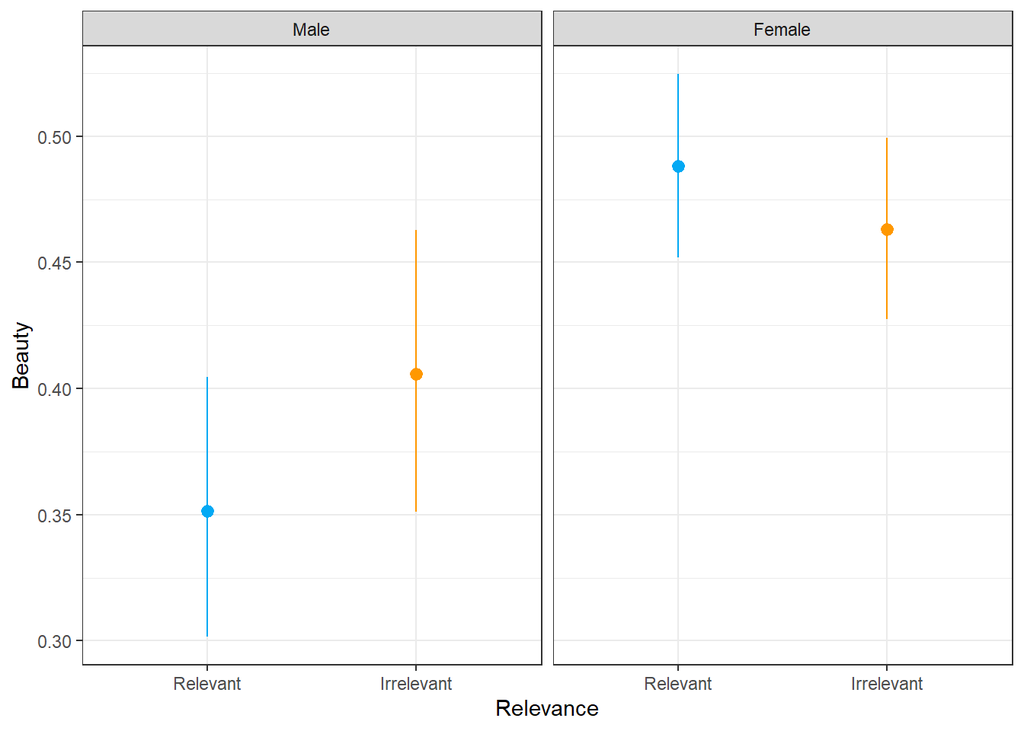

```r
estimate_relation(m_b) |>
  ggplot(aes(x=Relevance, y=Predicted)) +
  geom_pointrange(aes(ymin=CI_low, ymax=CI_high, color=Relevance), position=position_dodge(width=0.5)) +
  scale_color_manual(values=c("Relevant"="#03A9F4", "Irrelevant"="#FF9800"), guide = "none") +
  labs(y="Beauty") +
  facet_wrap(~Gender) +
  theme_bw()
```

**Reality**

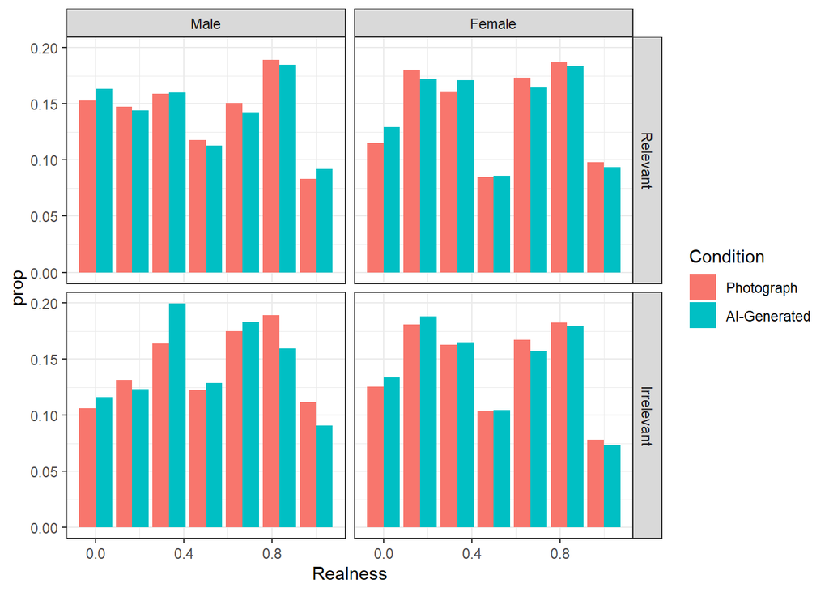

```r
dftask |>
  ggplot(aes(x=Realness, fill=Condition)) +
  geom_bar(aes(y = after_stat(prop)), position="dodge") +
  facet_grid(Relevance~Gender) +
  theme_bw()
```

The model evaluating the effect of Gender and Relevance on Realness ratings shows no significant effects.

```r
m_r<- glmmTMB::glmmTMB(Realness ~ Gender / Relevance +
                                       (Relevance | Participant) + (1|Stimulus),
                      data=dftask,
                      family=glmmTMB::ordbeta(),
                      control = glmmTMB::glmmTMBControl(parallel = 8))

results_table(m_r)
```

Fixed Effects

| Parameter | Coefficient | SE | 95% CI | z | p |
| --- | --- | --- | --- | --- | --- |
| (Intercept) | -0.12 | 0.08 | (-0.28, 0.04) | -1.45 | 0.147 |
| Gender (Female) | 0.14 | 0.09 | (-0.04, 0.32) | 1.55 | 0.122 |
| Gender (Male) × RelevanceIrrelevant | 0.09 | 0.06 | (-0.02, 0.21) | 1.55 | 0.122 |
| Gender (Female) × RelevanceIrrelevant | -0.04 | 0.04 | (-0.12, 0.03) | -1.17 | 0.244 |

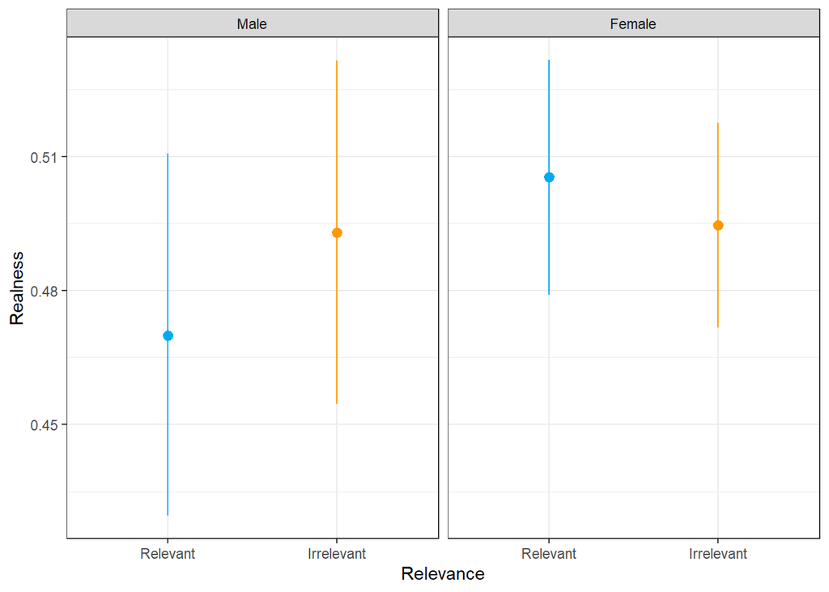

```r
estimate_relation(m_r) |>
  ggplot(aes(x=Relevance, y=Predicted)) +
  geom_pointrange(aes(ymin=CI_low, ymax=CI_high, color=Relevance), position=position_dodge(width=0.5)) +
  scale_color_manual(values=c("Relevant"="#03A9F4", "Irrelevant"="#FF9800"), guide = "none") +
  labs(y="Realness") +
  facet_wrap(~Gender) +
  theme_bw()
```

## Attractiveness

The variance decomposition (D_vour) further confirms that most of the explainable variance lies in participant-level intercepts (0.98) and stimulus-level intercepts (0.97), with smaller contributions from the random slopes.

```r
m_attractiveness <- glmmTMB::glmmTMB(Attractiveness ~ Gender / Relevance / Condition +
                                       (Condition | Participant) + (1|Stimulus),
                      data=dftask,
                      family=glmmTMB::ordbeta(),
                      control = glmmTMB::glmmTMBControl(parallel = 8))

performance::performance(m_attractiveness)
```

```
# Indices of model performance

AIC      |     AICc |      BIC | R2 (cond.) | R2 (marg.) |   ICC |  RMSE | Sigma
--------------------------------------------------------------------------------
6585.067 | 6585.088 | 6705.355 |      0.830 |      0.012 | 0.828 | 0.182 | 8.698
```

```r
results_table(m_attractiveness, filter="Condition")
```

Fixed Effects

| Parameter | Coefficient | SE | 95% CI | z | p |
| --- | --- | --- | --- | --- | --- |
| Gender (Male) × RelevanceRelevant × ConditionAI-Generated | 5.49e-03 | 0.03 | (-0.04, 0.06) | 0.22 | 0.829 |
| Gender (Female) × RelevanceRelevant × ConditionAI-Generated | -0.03 | 0.02 | (-0.06, 0.01) | -1.41 | 0.160 |
| Gender (Male) × RelevanceIrrelevant × ConditionAI-Generated | 0.02 | 0.06 | (-0.10, 0.13) | 0.33 | 0.739 |
| Gender (Female) × RelevanceIrrelevant × ConditionAI-Generated | -0.05 | 0.02 | (-0.08, -0.01) | -2.73 | 0.006 |

```r
performance::performance_dvour(m_attractiveness)
```

```
Cannot extract confidence intervals for random variance parameters from
  models with more than one grouping factor.
```

```
        Group             Parameter     D_vour
1 Participant           (Intercept) 0.98015322
2 Participant ConditionAI-Generated 0.09320755
3    Stimulus           (Intercept) 0.97355554
```

## Beauty

The model demonstrated strong conditional fit (R²_conditional = 0.858), indicating that most of the explained variance was due to random effects, particularly between participants (ICC = 0.849).

The variance decomposition (D_vour) further declares the smaller contributions from the random slopes.

```r
m_beauty <- glmmTMB::glmmTMB(Beauty ~ Gender / Relevance / Condition + (Condition | Participant) + (1|Stimulus),
                      data=dftask,
                      family=glmmTMB::ordbeta(),
                      control = glmmTMB::glmmTMBControl(parallel = 8))

results_table(m_beauty, filter="Condition")
```

Fixed Effects

| Parameter | Coefficient | SE | 95% CI | z | p |
| --- | --- | --- | --- | --- | --- |
| Gender (Male) × RelevanceRelevant × ConditionAI-Generated | -0.01 | 0.02 | (-0.06, 0.03) | -0.61 | 0.539 |
| Gender (Female) × RelevanceRelevant × ConditionAI-Generated | -0.05 | 0.02 | (-0.08, -0.01) | -2.82 | 0.005 |
| Gender (Male) × RelevanceIrrelevant × ConditionAI-Generated | -0.09 | 0.04 | (-0.18, -1.89e-03) | -2.00 | 0.045 |
| Gender (Female) × RelevanceIrrelevant × ConditionAI-Generated | -0.05 | 0.01 | (-0.08, -0.02) | -3.58 | < .001 |

```r
performance::performance(m_beauty)
```

```
# Indices of model performance

AIC       |      AICc |       BIC | R2 (cond.) | R2 (marg.) |   ICC |  RMSE | Sigma
-----------------------------------------------------------------------------------
-3010.979 | -3010.957 | -2890.691 |      0.858 |      0.062 | 0.849 | 0.175 | 9.737
```

```r
performance::performance_dvour(m_beauty)
```

```
Cannot extract confidence intervals for random variance parameters from
  models with more than one grouping factor.
```

```
        Group             Parameter    D_vour
1 Participant           (Intercept) 0.9787324
2 Participant ConditionAI-Generated 0.2571985
3    Stimulus           (Intercept) 0.9792688
```

```r
# modelbased::estimate_grouplevel(m_beauty)
```

## Trustworthiness

The model demonstrated strong conditional fit (R²_conditional = 0.845), indicating that most of the explained variance was due to random effects, particularly between participants (ICC = 0.844).

The variance decomposition (D_vour) further confirms that most of the explainable variance lies in participant-level intercepts (0.98) and stimulus-level intercepts (0.96).

```r
m_trustworthiness <- glmmTMB::glmmTMB(Trustworthiness ~ Gender / Relevance / Condition + (Condition|Participant) + (1|Stimulus),
                      data=dftask,
                      family=glmmTMB::ordbeta(),
                      control = glmmTMB::glmmTMBControl(parallel = 8))

results_table(m_trustworthiness, filter="Condition")
```

Fixed Effects

| Parameter | Coefficient | SE | 95% CI | z | p |
| --- | --- | --- | --- | --- | --- |
| Gender (Male) × RelevanceRelevant × ConditionAI-Generated | -0.05 | 0.03 | (-0.11, 5.00e-03) | -1.79 | 0.073 |
| Gender (Female) × RelevanceRelevant × ConditionAI-Generated | -0.12 | 0.02 | (-0.16, -0.07) | -5.39 | < .001 |
| Gender (Male) × RelevanceIrrelevant × ConditionAI-Generated | 0.01 | 0.05 | (-0.08, 0.11) | 0.28 | 0.782 |
| Gender (Female) × RelevanceIrrelevant × ConditionAI-Generated | -0.10 | 0.02 | (-0.14, -0.06) | -5.07 | < .001 |

```r
performance::performance(m_trustworthiness)
```

```
# Indices of model performance

AIC      |     AICc |      BIC | R2 (cond.) | R2 (marg.) |   ICC |  RMSE | Sigma
--------------------------------------------------------------------------------
-482.908 | -482.887 | -362.620 |      0.845 |      0.009 | 0.844 | 0.191 | 8.437
```

```r
performance::performance_dvour(m_trustworthiness)
```

```
Cannot extract confidence intervals for random variance parameters from
  models with more than one grouping factor.
```

```
        Group             Parameter    D_vour
1 Participant           (Intercept) 0.9762748
2 Participant ConditionAI-Generated 0.5348439
3    Stimulus           (Intercept) 0.9606022
```

## Coupling - Does fiction create a decoupling?

This model evaluates how beauty and image condition (e.g., AI-generated or not) jointly influence attractiveness ratings, and how this relationship is further moderated by the relevance of the image and the gender of the participant.

Beauty ratings are a strong predictor of attractiveness, but the strenght of this relationship varies by gender and relevance. Condition does not significantly moderate the beauty-attractiveness relationship, indicating that fiction does not create a decoupling between beauty and attractiveness.

```r
m_coupling1 <- glmmTMB::glmmTMB(Attractiveness ~ Gender / Relevance / (Beauty * Condition) +
                               (1 | Participant) + (1|Stimulus),
                      data=dftask,
                      family=glmmTMB::ordbeta(),
                      control = glmmTMB::glmmTMBControl(parallel = 8))

results_table(m_coupling1, filter="Beauty")
```

Fixed Effects

| Parameter | Coefficient | SE | 95% CI | z | p |
| --- | --- | --- | --- | --- | --- |
| Gender (Male) × RelevanceRelevant × Beauty | 3.64 | 0.08 | (3.48, 3.79) | 44.71 | < .001 |
| Gender (Female) × RelevanceRelevant × Beauty | 3.19 | 0.06 | (3.08, 3.31) | 56.24 | < .001 |
| Gender (Male) × RelevanceIrrelevant × Beauty | 2.47 | 0.17 | (2.15, 2.80) | 14.83 | < .001 |
| Gender (Female) × RelevanceIrrelevant × Beauty | 2.99 | 0.05 | (2.90, 3.09) | 59.60 | < .001 |
| Gender (Male) × RelevanceRelevant × Beauty × ConditionAI-Generated | 0.06 | 0.10 | (-0.14, 0.26) | 0.58 | 0.560 |
| Gender (Female) × RelevanceRelevant × Beauty × ConditionAI-Generated | -0.02 | 0.07 | (-0.16, 0.12) | -0.30 | 0.763 |
| Gender (Male) × RelevanceIrrelevant × Beauty × ConditionAI-Generated | 0.20 | 0.23 | (-0.26, 0.66) | 0.86 | 0.392 |
| Gender (Female) × RelevanceIrrelevant × Beauty × ConditionAI-Generated | 0.05 | 0.06 | (-0.07, 0.18) | 0.81 | 0.415 |

```r
performance::performance(m_coupling1)
```

```
# Indices of model performance

AIC       |      AICc |       BIC | R2 (cond.) | R2 (marg.) |   ICC |  RMSE |  Sigma
------------------------------------------------------------------------------------
-4147.632 | -4147.591 | -3979.228 |      0.903 |      0.485 | 0.812 | 0.135 | 13.765
```

This model evaluates how beauty and image condition (e.g., AI-generated or not) jointly influence trustworthiness ratings, and how this relationship is further moderated by the relevance of the image and the gender of the participant.

Beauty ratings are a strong predictor of trustowrthiness but condition does not significantly moderate the beauty-trustworthiness relationship. These findings indicate that fiction does not create a decoupling between beauty and trustworthiness.

```r
m_coupling2 <- glmmTMB::glmmTMB(Trustworthiness ~ Gender / Relevance / (Beauty * Condition) +
                               (1 | Participant) + (1|Stimulus),
                      data=dftask,
                      # family=glmmTMB::ordbeta(),
                      control = glmmTMB::glmmTMBControl(parallel = 8))

results_table(m_coupling2, filter="Beauty")
```

Fixed Effects

| Parameter | Coefficient | SE | 95% CI | z | p |
| --- | --- | --- | --- | --- | --- |
| Gender (Male) × RelevanceRelevant × Beauty | 0.43 | 0.02 | (0.39, 0.46) | 23.56 | < .001 |
| Gender (Female) × RelevanceRelevant × Beauty | 0.47 | 0.01 | (0.45, 0.50) | 37.33 | < .001 |
| Gender (Male) × RelevanceIrrelevant × Beauty | 0.45 | 0.03 | (0.39, 0.51) | 14.39 | < .001 |
| Gender (Female) × RelevanceIrrelevant × Beauty | 0.44 | 0.01 | (0.42, 0.46) | 37.82 | < .001 |
| Gender (Male) × RelevanceRelevant × Beauty × ConditionAI-Generated | -0.03 | 0.02 | (-0.08, 9.00e-03) | -1.56 | 0.119 |
| Gender (Female) × RelevanceRelevant × Beauty × ConditionAI-Generated | -0.03 | 0.02 | (-0.06, 4.98e-03) | -1.64 | 0.101 |
| Gender (Male) × RelevanceIrrelevant × Beauty × ConditionAI-Generated | -0.06 | 0.04 | (-0.14, 0.02) | -1.50 | 0.132 |
| Gender (Female) × RelevanceIrrelevant × Beauty × ConditionAI-Generated | 4.45e-03 | 0.01 | (-0.02, 0.03) | 0.31 | 0.757 |

```r
performance::performance(m_coupling2)
```

```
# Indices of model performance

AIC        |       AICc |        BIC | R2 (cond.) | R2 (marg.) |   ICC |  RMSE | Sigma
--------------------------------------------------------------------------------------
-13594.556 | -13594.522 | -13442.191 |      0.494 |      0.209 | 0.360 | 0.173 | 0.174
```

This model evaluates how attractiveness and image condition (e.g., AI-generated or not) jointly influence trustworthiness ratings, and how this relationship is further moderated by the relevance of the image and the gender of the participant.

Atractiveness ratings are a strong predictor of trustowrthiness, but the strenght of this relationship varies by gender and relevance.

Importantly, Condition (AI-generated vs. real) significantly moderates the attractiveness–trustworthiness relationship only for females rating irrelevant images. In this group, real photos are rated as less trustworthy compared to AI-generated images at comparable levels of attractiveness, indicating a weakening or decoupling of the usual link between attractiveness and trustworthiness when the image is irrelevant and real.

These results suggest that fiction (AI-generated images) affects the attractiveness–trustworthiness association for females evaluating irrelevant images, creating a decoupling between perceived beauty and trustworthiness in this context.

```r
m_coupling3 <- glmmTMB::glmmTMB(Trustworthiness ~ Gender / Relevance / (Attractiveness * Condition) +
                               (1 | Participant) + (1|Stimulus),
                      data=dftask,
                      # family=glmmTMB::ordbeta(),
                      control = glmmTMB::glmmTMBControl(parallel = 8))

results_table(m_coupling3, filter="Attractiveness")
```

Fixed Effects

| Parameter | Coefficient | SE | 95% CI | z | p |
| --- | --- | --- | --- | --- | --- |
| Gender (Male) × RelevanceRelevant × Attractiveness | 0.39 | 0.02 | (0.36, 0.43) | 22.90 | < .001 |
| Gender (Female) × RelevanceRelevant × Attractiveness | 0.42 | 0.01 | (0.39, 0.44) | 32.61 | < .001 |
| Gender (Male) × RelevanceIrrelevant × Attractiveness | 0.32 | 0.03 | (0.25, 0.38) | 9.35 | < .001 |
| Gender (Female) × RelevanceIrrelevant × Attractiveness | 0.37 | 0.01 | (0.35, 0.40) | 31.94 | < .001 |
| Gender (Male) × RelevanceRelevant × Attractiveness × ConditionAI-Generated | -0.04 | 0.02 | (-0.08, 2.87e-03) | -1.82 | 0.068 |
| Gender (Female) × RelevanceRelevant × Attractiveness × ConditionAI-Generated | -0.02 | 0.02 | (-0.05, 9.14e-03) | -1.39 | 0.164 |
| Gender (Male) × RelevanceIrrelevant × Attractiveness × ConditionAI-Generated | -0.06 | 0.04 | (-0.15, 0.02) | -1.49 | 0.136 |
| Gender (Female) × RelevanceIrrelevant × Attractiveness × ConditionAI-Generated | 0.04 | 0.01 | (0.02, 0.07) | 3.07 | 0.002 |

```r
performance::performance(m_coupling3)
```

```
# Indices of model performance

AIC        |       AICc |        BIC | R2 (cond.) | R2 (marg.) |   ICC |  RMSE | Sigma
--------------------------------------------------------------------------------------
-12810.602 | -12810.568 | -12658.237 |      0.488 |      0.170 | 0.383 | 0.176 | 0.177
```

## Moderator

### Attractiveness

**Honest-Humility**

```r
m1 <- glmmTMB::glmmTMB(Attractiveness ~ Gender / Relevance / (Condition * HEXACO18_HonestyHumility) +
                                       (1 | Participant) + (1|Stimulus),
                      data=dftask,
                      family=glmmTMB::ordbeta(),
                      control = glmmTMB::glmmTMBControl(parallel = 8))

results_table(m1, filter="HEXACO18_HonestyHumility")
```

Fixed Effects

| Parameter | Coefficient | SE | 95% CI | z | p |
| --- | --- | --- | --- | --- | --- |
| Gender (Male) × RelevanceRelevant × HEXACO18 HonestyHumility | 0.10 | 0.10 | (-0.10, 0.29) | 0.98 | 0.325 |
| Gender (Female) × RelevanceRelevant × HEXACO18 HonestyHumility | 0.03 | 0.05 | (-0.07, 0.14) | 0.61 | 0.539 |
| Gender (Male) × RelevanceIrrelevant × HEXACO18 HonestyHumility | 0.17 | 0.11 | (-0.03, 0.38) | 1.63 | 0.102 |
| Gender (Female) × RelevanceIrrelevant × HEXACO18 HonestyHumility | 0.02 | 0.05 | (-0.09, 0.12) | 0.28 | 0.777 |
| Gender (Male) × RelevanceRelevant × ConditionAI-Generated × HEXACO18 HonestyHumility | 6.39e-03 | 0.02 | (-0.03, 0.04) | 0.35 | 0.723 |
| Gender (Female) × RelevanceRelevant × ConditionAI-Generated × HEXACO18 HonestyHumility | -5.61e-03 | 0.01 | (-0.03, 0.02) | -0.40 | 0.688 |
| Gender (Male) × RelevanceIrrelevant × ConditionAI-Generated × HEXACO18 HonestyHumility | -0.02 | 0.05 | (-0.12, 0.08) | -0.35 | 0.725 |
| Gender (Female) × RelevanceIrrelevant × ConditionAI-Generated × HEXACO18 HonestyHumility | -4.32e-04 | 0.01 | (-0.02, 0.02) | -0.04 | 0.971 |

**Openness**

```r
m2 <- glmmTMB::glmmTMB(Attractiveness ~ Gender / Relevance / (Condition * HEXACO18_Openness) +
                                       (1 | Participant) + (1|Stimulus),
                      data=dftask,
                      family=glmmTMB::ordbeta(),
                      control = glmmTMB::glmmTMBControl(parallel = 8))

results_table(m2, filter="HEXACO18_Openness")
```

Fixed Effects

| Parameter | Coefficient | SE | 95% CI | z | p |
| --- | --- | --- | --- | --- | --- |
| Gender (Male) × RelevanceRelevant × HEXACO18 Openness | -0.07 | 0.10 | (-0.25, 0.12) | -0.70 | 0.485 |
| Gender (Female) × RelevanceRelevant × HEXACO18 Openness | -0.05 | 0.06 | (-0.16, 0.07) | -0.80 | 0.426 |
| Gender (Male) × RelevanceIrrelevant × HEXACO18 Openness | 0.09 | 0.10 | (-0.10, 0.28) | 0.90 | 0.369 |
| Gender (Female) × RelevanceIrrelevant × HEXACO18 Openness | -0.02 | 0.06 | (-0.13, 0.09) | -0.38 | 0.702 |
| Gender (Male) × RelevanceRelevant × ConditionAI-Generated × HEXACO18 Openness | 0.03 | 0.02 | (-6.87e-03, 0.06) | 1.56 | 0.118 |
| Gender (Female) × RelevanceRelevant × ConditionAI-Generated × HEXACO18 Openness | -0.02 | 0.01 | (-0.04, 0.01) | -1.07 | 0.287 |
| Gender (Male) × RelevanceIrrelevant × ConditionAI-Generated × HEXACO18 Openness | -0.02 | 0.03 | (-0.09, 0.05) | -0.64 | 0.521 |
| Gender (Female) × RelevanceIrrelevant × ConditionAI-Generated × HEXACO18 Openness | -0.03 | 0.01 | (-0.06, -8.57e-03) | -2.64 | 0.008 |

```r
predao <- estimate_relation(m2, lenght = 50)

p1 <- predao |>
  filter(Gender== "Female") |>
   ggplot(aes(x=HEXACO18_Openness , y=Predicted)) +
  geom_ribbon(aes(ymin=CI_low, ymax=CI_high, fill=Condition), alpha=0.3) +
  geom_line(aes(color=Condition), linewidth=1, key_glyph = draw_key_rect) +
  # geom_text(data=stars1, aes(x=x, y=y, label=label, color=Condition), hjust=0.5, size=3) +
  geom_text(data=data.frame(Relevance=as.factor("Irrelevant"), x=4, y=0.3156, label="**"), aes(x=x, y=y, label=label), hjust=0.5, color="#424242", size=6) +
  facet_grid(~Relevance) +
  scale_y_continuous(labels=scales::percent) +
  scale_color_manual(values=c("AI-Generated"="#2196F3", "Photograph"="#F44336")) +
  scale_fill_manual(values=c("AI-Generated"="#2196F3", "Photograph"="#F44336"), guide="none") +
  theme_minimal() +
  theme(axis.text.y = element_text(size = 8),
        strip.placement = "outside",
        strip.background.x = element_rect(fill=c("lightgrey"), color=NA),
        strip.text.x = element_text(size = 10),
        strip.text.y = element_text(size = 10),
        axis.text.x = element_text(size=9, color="black"),
        legend.text = element_text(size = 10)) +
  labs(y="Attractiveness\n", fill="Images presented as:", color="Images presented as:",
       x = "\nOppeness to Experiences",
       caption ="Note. Females Only")
```

**Emotionality**

```r
m3 <- glmmTMB::glmmTMB(Attractiveness ~ Gender / Relevance / (Condition * HEXACO18_Emotionality) +
                                       (1 | Participant) + (1|Stimulus),
                      data=dftask,
                      family=glmmTMB::ordbeta(),
                      control = glmmTMB::glmmTMBControl(parallel = 8))

results_table(m3, filter="HEXACO18_Emotionality")
```

Fixed Effects

| Parameter | Coefficient | SE | 95% CI | z | p |
| --- | --- | --- | --- | --- | --- |
| Gender (Male) × RelevanceRelevant × HEXACO18 Emotionality | -0.05 | 0.11 | (-0.26, 0.17) | -0.42 | 0.676 |
| Gender (Female) × RelevanceRelevant × HEXACO18 Emotionality | -0.03 | 0.06 | (-0.15, 0.09) | -0.55 | 0.580 |
| Gender (Male) × RelevanceIrrelevant × HEXACO18 Emotionality | -0.14 | 0.12 | (-0.37, 0.09) | -1.19 | 0.235 |
| Gender (Female) × RelevanceIrrelevant × HEXACO18 Emotionality | -0.03 | 0.06 | (-0.15, 0.09) | -0.45 | 0.654 |
| Gender (Male) × RelevanceRelevant × ConditionAI-Generated × HEXACO18 Emotionality | 0.02 | 0.02 | (-0.02, 0.06) | 0.85 | 0.398 |
| Gender (Female) × RelevanceRelevant × ConditionAI-Generated × HEXACO18 Emotionality | 0.01 | 0.01 | (-0.02, 0.04) | 0.76 | 0.450 |
| Gender (Male) × RelevanceIrrelevant × ConditionAI-Generated × HEXACO18 Emotionality | 0.03 | 0.05 | (-0.07, 0.13) | 0.57 | 0.571 |
| Gender (Female) × RelevanceIrrelevant × ConditionAI-Generated × HEXACO18 Emotionality | -4.19e-03 | 0.01 | (-0.03, 0.02) | -0.32 | 0.748 |

**Extraversion**

```r
m4 <- glmmTMB::glmmTMB(Attractiveness ~ Gender / Relevance / (Condition * HEXACO18_Extraversion) +
                                       (1 | Participant) + (1|Stimulus),
                      data=dftask,
                      family=glmmTMB::ordbeta(),
                      control = glmmTMB::glmmTMBControl(parallel = 8))

results_table(m4, filter="HEXACO18_Extraversion")
```

Fixed Effects

| Parameter | Coefficient | SE | 95% CI | z | p |
| --- | --- | --- | --- | --- | --- |
| Gender (Male) × RelevanceRelevant × HEXACO18 Extraversion | 0.04 | 0.08 | (-0.12, 0.20) | 0.50 | 0.620 |
| Gender (Female) × RelevanceRelevant × HEXACO18 Extraversion | -0.01 | 0.05 | (-0.11, 0.09) | -0.20 | 0.844 |
| Gender (Male) × RelevanceIrrelevant × HEXACO18 Extraversion | 0.15 | 0.08 | (-0.01, 0.32) | 1.83 | 0.067 |
| Gender (Female) × RelevanceIrrelevant × HEXACO18 Extraversion | -0.05 | 0.05 | (-0.15, 0.04) | -1.08 | 0.280 |
| Gender (Male) × RelevanceRelevant × ConditionAI-Generated × HEXACO18 Extraversion | -0.02 | 0.02 | (-0.05, 0.02) | -1.02 | 0.307 |
| Gender (Female) × RelevanceRelevant × ConditionAI-Generated × HEXACO18 Extraversion | -0.01 | 0.01 | (-0.04, 0.01) | -0.95 | 0.342 |
| Gender (Male) × RelevanceIrrelevant × ConditionAI-Generated × HEXACO18 Extraversion | 0.01 | 0.03 | (-0.06, 0.08) | 0.30 | 0.761 |
| Gender (Female) × RelevanceIrrelevant × ConditionAI-Generated × HEXACO18 Extraversion | 1.98e-03 | 0.01 | (-0.02, 0.02) | 0.19 | 0.846 |

**Agreeableness**

```r
m5 <- glmmTMB::glmmTMB(Attractiveness ~ Gender / Relevance / (Condition * HEXACO18_Agreeableness) +
                                       (1 | Participant) + (1|Stimulus),
                      data=dftask,
                      family=glmmTMB::ordbeta(),
                      control = glmmTMB::glmmTMBControl(parallel = 8))

results_table(m5, filter="HEXACO18_Agreeableness")
```

Fixed Effects

| Parameter | Coefficient | SE | 95% CI | z | p |
| --- | --- | --- | --- | --- | --- |
| Gender (Male) × RelevanceRelevant × HEXACO18 Agreeableness | 0.13 | 0.13 | (-0.12, 0.38) | 1.02 | 0.309 |
| Gender (Female) × RelevanceRelevant × HEXACO18 Agreeableness | 0.11 | 0.06 | (-0.01, 0.23) | 1.73 | 0.083 |
| Gender (Male) × RelevanceIrrelevant × HEXACO18 Agreeableness | -2.69e-03 | 0.14 | (-0.27, 0.27) | -0.02 | 0.984 |
| Gender (Female) × RelevanceIrrelevant × HEXACO18 Agreeableness | 0.12 | 0.06 | (-9.27e-04, 0.24) | 1.94 | 0.052 |
| Gender (Male) × RelevanceRelevant × ConditionAI-Generated × HEXACO18 Agreeableness | -3.91e-03 | 0.02 | (-0.05, 0.04) | -0.16 | 0.873 |
| Gender (Female) × RelevanceRelevant × ConditionAI-Generated × HEXACO18 Agreeableness | 2.40e-03 | 0.02 | (-0.03, 0.03) | 0.15 | 0.883 |
| Gender (Male) × RelevanceIrrelevant × ConditionAI-Generated × HEXACO18 Agreeableness | -0.04 | 0.07 | (-0.17, 0.09) | -0.64 | 0.525 |
| Gender (Female) × RelevanceIrrelevant × ConditionAI-Generated × HEXACO18 Agreeableness | -0.02 | 0.01 | (-0.05, 2.54e-03) | -1.77 | 0.077 |

**Conscientiousness**

```r
m6 <- glmmTMB::glmmTMB(Attractiveness ~ Gender / Relevance / (Condition * HEXACO18_Conscientiousness) +
                                       (1 | Participant) + (1|Stimulus),
                      data=dftask,
                      family=glmmTMB::ordbeta(),
                      control = glmmTMB::glmmTMBControl(parallel = 8))

results_table(m6, filter="HEXACO18_Conscientiousness")
```

Fixed Effects

| Parameter | Coefficient | SE | 95% CI | z | p |
| --- | --- | --- | --- | --- | --- |
| Gender (Male) × RelevanceRelevant × HEXACO18 Conscientiousness | 0.11 | 0.09 | (-0.07, 0.29) | 1.18 | 0.236 |
| Gender (Female) × RelevanceRelevant × HEXACO18 Conscientiousness | 0.02 | 0.05 | (-0.08, 0.11) | 0.38 | 0.704 |
| Gender (Male) × RelevanceIrrelevant × HEXACO18 Conscientiousness | -0.01 | 0.09 | (-0.19, 0.17) | -0.11 | 0.914 |
| Gender (Female) × RelevanceIrrelevant × HEXACO18 Conscientiousness | 0.03 | 0.05 | (-0.06, 0.12) | 0.68 | 0.494 |
| Gender (Male) × RelevanceRelevant × ConditionAI-Generated × HEXACO18 Conscientiousness | -1.76e-03 | 0.02 | (-0.04, 0.03) | -0.10 | 0.922 |
| Gender (Female) × RelevanceRelevant × ConditionAI-Generated × HEXACO18 Conscientiousness | 0.02 | 0.01 | (-8.26e-03, 0.04) | 1.32 | 0.188 |
| Gender (Male) × RelevanceIrrelevant × ConditionAI-Generated × HEXACO18 Conscientiousness | -0.04 | 0.04 | (-0.11, 0.03) | -1.23 | 0.218 |
| Gender (Female) × RelevanceIrrelevant × ConditionAI-Generated × HEXACO18 Conscientiousness | -0.01 | 0.01 | (-0.03, 7.62e-03) | -1.21 | 0.226 |

### Beauty

**Honest-Humility**

```r
m1 <- glmmTMB::glmmTMB(Beauty ~ Gender / Relevance / (Condition * HEXACO18_HonestyHumility) +
                                       (1 | Participant) + (1|Stimulus),
                      data=dftask,
                      family=glmmTMB::ordbeta(),
                      control = glmmTMB::glmmTMBControl(parallel = 8))

results_table(m1, filter="HEXACO18_HonestyHumility")
```

Fixed Effects

| Parameter | Coefficient | SE | 95% CI | z | p |
| --- | --- | --- | --- | --- | --- |
| Gender (Male) × RelevanceRelevant × HEXACO18 HonestyHumility | 0.17 | 0.07 | (0.03, 0.31) | 2.33 | 0.020 |
| Gender (Female) × RelevanceRelevant × HEXACO18 HonestyHumility | 0.10 | 0.04 | (0.02, 0.18) | 2.47 | 0.014 |
| Gender (Male) × RelevanceIrrelevant × HEXACO18 HonestyHumility | 0.25 | 0.08 | (0.10, 0.40) | 3.20 | 0.001 |
| Gender (Female) × RelevanceIrrelevant × HEXACO18 HonestyHumility | 0.10 | 0.04 | (0.02, 0.17) | 2.44 | 0.015 |
| Gender (Male) × RelevanceRelevant × ConditionAI-Generated × HEXACO18 HonestyHumility | 0.02 | 0.02 | (-0.01, 0.05) | 1.14 | 0.255 |
| Gender (Female) × RelevanceRelevant × ConditionAI-Generated × HEXACO18 HonestyHumility | 0.02 | 0.01 | (-1.52e-04, 0.05) | 1.95 | 0.051 |
| Gender (Male) × RelevanceIrrelevant × ConditionAI-Generated × HEXACO18 HonestyHumility | -0.03 | 0.04 | (-0.10, 0.05) | -0.71 | 0.478 |
| Gender (Female) × RelevanceIrrelevant × ConditionAI-Generated × HEXACO18 HonestyHumility | -6.86e-03 | 0.01 | (-0.03, 0.01) | -0.68 | 0.498 |

**Openness**

```r
m2 <- glmmTMB::glmmTMB(Beauty ~ Gender / Relevance / (Condition * HEXACO18_Openness) +
                                       (1 | Participant) + (1|Stimulus),
                      data=dftask,
                      family=glmmTMB::ordbeta(),
                      control = glmmTMB::glmmTMBControl(parallel = 8))

results_table(m2, filter="HEXACO18_Openness")
```

Fixed Effects

| Parameter | Coefficient | SE | 95% CI | z | p |
| --- | --- | --- | --- | --- | --- |
| Gender (Male) × RelevanceRelevant × HEXACO18 Openness | -0.07 | 0.07 | (-0.22, 0.07) | -1.02 | 0.307 |
| Gender (Female) × RelevanceRelevant × HEXACO18 Openness | 0.04 | 0.04 | (-0.04, 0.12) | 0.95 | 0.342 |
| Gender (Male) × RelevanceIrrelevant × HEXACO18 Openness | 0.05 | 0.07 | (-0.10, 0.20) | 0.67 | 0.500 |
| Gender (Female) × RelevanceIrrelevant × HEXACO18 Openness | 0.05 | 0.04 | (-0.04, 0.13) | 1.10 | 0.272 |
| Gender (Male) × RelevanceRelevant × ConditionAI-Generated × HEXACO18 Openness | 0.02 | 0.02 | (-6.15e-03, 0.06) | 1.57 | 0.117 |
| Gender (Female) × RelevanceRelevant × ConditionAI-Generated × HEXACO18 Openness | 0.01 | 0.01 | (-0.01, 0.04) | 1.08 | 0.279 |
| Gender (Male) × RelevanceIrrelevant × ConditionAI-Generated × HEXACO18 Openness | 0.04 | 0.03 | (-0.02, 0.09) | 1.26 | 0.208 |
| Gender (Female) × RelevanceIrrelevant × ConditionAI-Generated × HEXACO18 Openness | -0.02 | 0.01 | (-0.04, 3.85e-03) | -1.60 | 0.109 |

**Emotionality**

```r
m3 <- glmmTMB::glmmTMB(Beauty ~ Gender / Relevance / (Condition * HEXACO18_Emotionality) +
                                       (1 | Participant) + (1|Stimulus),
                      data=dftask,
                      family=glmmTMB::ordbeta(),
                      control = glmmTMB::glmmTMBControl(parallel = 8))

results_table(m3, filter="HEXACO18_Emotionality")
```

Fixed Effects

| Parameter | Coefficient | SE | 95% CI | z | p |
| --- | --- | --- | --- | --- | --- |
| Gender (Male) × RelevanceRelevant × HEXACO18 Emotionality | -0.12 | 0.08 | (-0.29, 0.04) | -1.48 | 0.140 |
| Gender (Female) × RelevanceRelevant × HEXACO18 Emotionality | -3.28e-03 | 0.05 | (-0.09, 0.09) | -0.07 | 0.943 |
| Gender (Male) × RelevanceIrrelevant × HEXACO18 Emotionality | -0.16 | 0.09 | (-0.33, 0.01) | -1.83 | 0.067 |
| Gender (Female) × RelevanceIrrelevant × HEXACO18 Emotionality | 0.03 | 0.05 | (-0.06, 0.12) | 0.65 | 0.517 |
| Gender (Male) × RelevanceRelevant × ConditionAI-Generated × HEXACO18 Emotionality | 1.00e-03 | 0.02 | (-0.04, 0.04) | 0.05 | 0.957 |
| Gender (Female) × RelevanceRelevant × ConditionAI-Generated × HEXACO18 Emotionality | 7.10e-03 | 0.01 | (-0.02, 0.03) | 0.55 | 0.583 |
| Gender (Male) × RelevanceIrrelevant × ConditionAI-Generated × HEXACO18 Emotionality | -0.03 | 0.04 | (-0.09, 0.04) | -0.73 | 0.463 |
| Gender (Female) × RelevanceIrrelevant × ConditionAI-Generated × HEXACO18 Emotionality | -7.66e-03 | 0.01 | (-0.03, 0.02) | -0.65 | 0.513 |

**Extraversion**

```r
m4 <- glmmTMB::glmmTMB(Beauty ~ Gender / Relevance / (Condition * HEXACO18_Extraversion) +
                                       (1 | Participant) + (1|Stimulus),
                      data=dftask,
                      family=glmmTMB::ordbeta(),
                      control = glmmTMB::glmmTMBControl(parallel = 8))

results_table(m4, filter="HEXACO18_Extraversion")
```

Fixed Effects

| Parameter | Coefficient | SE | 95% CI | z | p |
| --- | --- | --- | --- | --- | --- |
| Gender (Male) × RelevanceRelevant × HEXACO18 Extraversion | 0.02 | 0.06 | (-0.10, 0.14) | 0.26 | 0.792 |
| Gender (Female) × RelevanceRelevant × HEXACO18 Extraversion | -0.02 | 0.04 | (-0.10, 0.06) | -0.51 | 0.609 |
| Gender (Male) × RelevanceIrrelevant × HEXACO18 Extraversion | 0.03 | 0.06 | (-0.10, 0.15) | 0.43 | 0.664 |
| Gender (Female) × RelevanceIrrelevant × HEXACO18 Extraversion | -0.07 | 0.04 | (-0.15, 2.90e-03) | -1.88 | 0.060 |
| Gender (Male) × RelevanceRelevant × ConditionAI-Generated × HEXACO18 Extraversion | -9.13e-03 | 0.02 | (-0.04, 0.02) | -0.59 | 0.555 |
| Gender (Female) × RelevanceRelevant × ConditionAI-Generated × HEXACO18 Extraversion | -1.63e-03 | 0.01 | (-0.02, 0.02) | -0.14 | 0.890 |
| Gender (Male) × RelevanceIrrelevant × ConditionAI-Generated × HEXACO18 Extraversion | 0.03 | 0.03 | (-0.02, 0.08) | 1.32 | 0.188 |
| Gender (Female) × RelevanceIrrelevant × ConditionAI-Generated × HEXACO18 Extraversion | 0.01 | 9.11e-03 | (-5.35e-03, 0.03) | 1.37 | 0.170 |

**Agreeableness**

```r
m5 <- glmmTMB::glmmTMB(Beauty ~ Gender / Relevance / (Condition * HEXACO18_Agreeableness) +
                                       (1 | Participant) + (1|Stimulus),
                      data=dftask,
                      family=glmmTMB::ordbeta(),
                      control = glmmTMB::glmmTMBControl(parallel = 8))

results_table(m5, filter="HEXACO18_Agreeableness")
```

Fixed Effects

| Parameter | Coefficient | SE | 95% CI | z | p |
| --- | --- | --- | --- | --- | --- |
| Gender (Male) × RelevanceRelevant × HEXACO18 Agreeableness | 0.12 | 0.10 | (-0.07, 0.31) | 1.22 | 0.224 |
| Gender (Female) × RelevanceRelevant × HEXACO18 Agreeableness | 0.07 | 0.05 | (-0.03, 0.16) | 1.41 | 0.158 |
| Gender (Male) × RelevanceIrrelevant × HEXACO18 Agreeableness | 0.15 | 0.10 | (-0.05, 0.35) | 1.50 | 0.133 |
| Gender (Female) × RelevanceIrrelevant × HEXACO18 Agreeableness | 0.08 | 0.05 | (-9.69e-03, 0.17) | 1.75 | 0.080 |
| Gender (Male) × RelevanceRelevant × ConditionAI-Generated × HEXACO18 Agreeableness | -0.02 | 0.02 | (-0.06, 0.02) | -0.86 | 0.390 |
| Gender (Female) × RelevanceRelevant × ConditionAI-Generated × HEXACO18 Agreeableness | -0.01 | 0.01 | (-0.04, 0.02) | -0.75 | 0.452 |
| Gender (Male) × RelevanceIrrelevant × ConditionAI-Generated × HEXACO18 Agreeableness | -0.05 | 0.04 | (-0.13, 0.03) | -1.18 | 0.237 |
| Gender (Female) × RelevanceIrrelevant × ConditionAI-Generated × HEXACO18 Agreeableness | -0.01 | 0.01 | (-0.04, 0.01) | -1.08 | 0.281 |

**Conscientiousness**

Additionally, conscientiousness significantly moderated males’ ratings of relevant images that are presented as photos.

```r
m6 <- glmmTMB::glmmTMB(Beauty ~ Gender / Relevance / (Condition * HEXACO18_Conscientiousness) +
                                       (1 | Participant) + (1|Stimulus),
                      data=dftask,
                      family=glmmTMB::ordbeta(),
                      control = glmmTMB::glmmTMBControl(parallel = 8))

results_table(m6, filter="HEXACO18_Conscientiousness")
```

Fixed Effects

| Parameter | Coefficient | SE | 95% CI | z | p |
| --- | --- | --- | --- | --- | --- |
| Gender (Male) × RelevanceRelevant × HEXACO18 Conscientiousness | 0.18 | 0.07 | (0.04, 0.31) | 2.56 | 0.011 |
| Gender (Female) × RelevanceRelevant × HEXACO18 Conscientiousness | -0.03 | 0.04 | (-0.10, 0.04) | -0.94 | 0.346 |
| Gender (Male) × RelevanceIrrelevant × HEXACO18 Conscientiousness | 0.13 | 0.07 | (-8.40e-03, 0.27) | 1.84 | 0.066 |
| Gender (Female) × RelevanceIrrelevant × HEXACO18 Conscientiousness | -0.04 | 0.04 | (-0.10, 0.03) | -1.00 | 0.316 |
| Gender (Male) × RelevanceRelevant × ConditionAI-Generated × HEXACO18 Conscientiousness | 4.28e-03 | 0.02 | (-0.03, 0.04) | 0.26 | 0.793 |
| Gender (Female) × RelevanceRelevant × ConditionAI-Generated × HEXACO18 Conscientiousness | 0.02 | 0.01 | (2.76e-03, 0.05) | 2.20 | 0.028 |
| Gender (Male) × RelevanceIrrelevant × ConditionAI-Generated × HEXACO18 Conscientiousness | -2.81e-03 | 0.03 | (-0.06, 0.05) | -0.10 | 0.920 |
| Gender (Female) × RelevanceIrrelevant × ConditionAI-Generated × HEXACO18 Conscientiousness | -7.55e-03 | 9.11e-03 | (-0.03, 0.01) | -0.83 | 0.407 |

```r
predbc <- estimate_relation(m6, lenght = 50)

p2 <- predbc |>
  filter(Gender== "Female") |>
   ggplot(aes(x=HEXACO18_Conscientiousness , y=Predicted)) +
  geom_ribbon(aes(ymin=CI_low, ymax=CI_high, fill=Condition), alpha=0.3) +
  geom_line(aes(color=Condition), linewidth=1, key_glyph = draw_key_rect) +
  # geom_text(data=stars1, aes(x=x, y=y, label=label, color=Condition), hjust=0.5, size=3) +
  geom_text(data=data.frame(Relevance=as.factor("Relevant"), x=3, y=0.493, label="*"), aes(x=x, y=y, label=label), hjust=0.5, color="#424242", size=6) +
  facet_grid(~Relevance) +
  scale_y_continuous(labels=scales::percent) +
  scale_color_manual(values=c("AI-Generated"="#2196F3", "Photograph"="#F44336")) +
  scale_fill_manual(values=c("AI-Generated"="#2196F3", "Photograph"="#F44336"), guide="none") +
  theme_minimal() +
  theme(axis.text.y = element_text(size = 8),
        strip.placement = "outside",
        strip.background.x = element_rect(fill=c("lightgrey"), color=NA),
        strip.text.x = element_text(size = 10),
        strip.text.y = element_text(size = 10),
        axis.text.x = element_text(size=9, color="black"),
        legend.text = element_text(size = 10)) +
  labs(y="Beauty", fill="Images presented as:", color="Images presented as:",
       x = "\nConscientiousness")
```

### Trustworthiness

**Honest-Humility**

```r
m1 <- glmmTMB::glmmTMB(Trustworthiness ~ Gender / Relevance / (Condition * HEXACO18_HonestyHumility) +
                                       (1 | Participant) + (1|Stimulus),
                      data=dftask,
                      family=glmmTMB::ordbeta(),
                      control = glmmTMB::glmmTMBControl(parallel = 8))

results_table(m1, filter="HEXACO18_HonestyHumility")
```

Fixed Effects

| Parameter | Coefficient | SE | 95% CI | z | p |
| --- | --- | --- | --- | --- | --- |
| Gender (Male) × RelevanceRelevant × HEXACO18 HonestyHumility | 0.16 | 0.08 | (3.72e-03, 0.31) | 2.01 | 0.045 |
| Gender (Female) × RelevanceRelevant × HEXACO18 HonestyHumility | 0.13 | 0.04 | (0.05, 0.21) | 3.01 | 0.003 |
| Gender (Male) × RelevanceIrrelevant × HEXACO18 HonestyHumility | 0.19 | 0.08 | (0.03, 0.35) | 2.34 | 0.019 |
| Gender (Female) × RelevanceIrrelevant × HEXACO18 HonestyHumility | 0.10 | 0.04 | (0.02, 0.18) | 2.39 | 0.017 |
| Gender (Male) × RelevanceRelevant × ConditionAI-Generated × HEXACO18 HonestyHumility | 0.01 | 0.02 | (-0.02, 0.04) | 0.67 | 0.504 |
| Gender (Female) × RelevanceRelevant × ConditionAI-Generated × HEXACO18 HonestyHumility | 1.54e-03 | 0.01 | (-0.02, 0.03) | 0.12 | 0.903 |
| Gender (Male) × RelevanceIrrelevant × ConditionAI-Generated × HEXACO18 HonestyHumility | 6.90e-03 | 0.04 | (-0.07, 0.08) | 0.19 | 0.853 |
| Gender (Female) × RelevanceIrrelevant × ConditionAI-Generated × HEXACO18 HonestyHumility | -0.02 | 0.01 | (-0.04, -1.70e-03) | -2.12 | 0.034 |

```r
predthh <- estimate_relation(m1, lenght = 50)

p3 <- predthh |>
  filter(Gender== "Female") |>
   ggplot(aes(x=HEXACO18_HonestyHumility , y=Predicted)) +
  geom_ribbon(aes(ymin=CI_low, ymax=CI_high, fill=Condition), alpha=0.3) +
  geom_line(aes(color=Condition), linewidth=1, key_glyph = draw_key_rect) +
  # geom_text(data=stars1, aes(x=x, y=y, label=label, color=Condition), hjust=0.5, size=3) +
  geom_text(data=data.frame(Relevance=as.factor("Irrelevant"), x=4, y=0.485, label="*"), aes(x=x, y=y, label=label), hjust=0.5, color="#424242", size=6) +
  facet_grid(~Relevance) +
  scale_y_continuous(labels=scales::percent) +
  scale_color_manual(values=c("AI-Generated"="#2196F3", "Photograph"="#F44336")) +
  scale_fill_manual(values=c("AI-Generated"="#2196F3", "Photograph"="#F44336"), guide="none") +
  theme_minimal() +
  theme(axis.text.y = element_text(size = 8),
        strip.placement = "outside",
        strip.background.x = element_rect(fill=c("lightgrey"), color=NA),
        strip.text.x = element_text(size = 10),
        strip.text.y = element_text(size = 10),
        axis.text.x = element_text(size=9, color="black"),
        legend.text = element_text(size = 10)) +
  labs(y="Trustworthiness\n", fill="Images presented as:", color="Images presented as:",
       x = "\nHonesty-Humility",
       caption ="Note. Females Only")
```

**Openness**

Openness significantly moderated females’ ratings of irrelevant AI-generated images, such that higher Openness was associated with lower trustworthiness ratings. No other effects were significant.

```r
m2 <- glmmTMB::glmmTMB(Trustworthiness ~ Gender / Relevance / (Condition * HEXACO18_Openness) +
                                       (1 | Participant) + (1|Stimulus),
                      data=dftask,
                      family=glmmTMB::ordbeta(),
                      control = glmmTMB::glmmTMBControl(parallel = 8))

results_table(m2, filter="HEXACO18_Openness")
```

Fixed Effects

| Parameter | Coefficient | SE | 95% CI | z | p |
| --- | --- | --- | --- | --- | --- |
| Gender (Male) × RelevanceRelevant × HEXACO18 Openness | -0.05 | 0.08 | (-0.21, 0.10) | -0.69 | 0.487 |
| Gender (Female) × RelevanceRelevant × HEXACO18 Openness | -0.02 | 0.05 | (-0.11, 0.07) | -0.45 | 0.650 |
| Gender (Male) × RelevanceIrrelevant × HEXACO18 Openness | 5.17e-03 | 0.08 | (-0.15, 0.16) | 0.06 | 0.948 |
| Gender (Female) × RelevanceIrrelevant × HEXACO18 Openness | -0.01 | 0.05 | (-0.10, 0.08) | -0.23 | 0.817 |
| Gender (Male) × RelevanceRelevant × ConditionAI-Generated × HEXACO18 Openness | 0.01 | 0.02 | (-0.02, 0.04) | 0.75 | 0.455 |
| Gender (Female) × RelevanceRelevant × ConditionAI-Generated × HEXACO18 Openness | -9.65e-03 | 0.01 | (-0.03, 0.02) | -0.75 | 0.451 |
| Gender (Male) × RelevanceIrrelevant × ConditionAI-Generated × HEXACO18 Openness | -0.04 | 0.03 | (-0.10, 0.02) | -1.37 | 0.169 |
| Gender (Female) × RelevanceIrrelevant × ConditionAI-Generated × HEXACO18 Openness | -0.02 | 0.01 | (-0.05, -3.16e-05) | -1.96 | 0.050 |

```r
predto <- estimate_relation(m2, lenght = 50)

p4 <- predto |>
  filter(Gender== "Female") |>
   ggplot(aes(x=HEXACO18_Openness , y=Predicted)) +
  geom_ribbon(aes(ymin=CI_low, ymax=CI_high, fill=Condition), alpha=0.3) +
  geom_line(aes(color=Condition), linewidth=1, key_glyph = draw_key_rect) +
  # geom_text(data=stars1, aes(x=x, y=y, label=label, color=Condition), hjust=0.5, size=3) +
  geom_text(data=data.frame(Relevance=as.factor("Irrelevant"), x=4, y=0.485, label="*"), aes(x=x, y=y, label=label), hjust=0.5, color="#424242", size=6) +
  facet_grid(~Relevance) +
  scale_y_continuous(labels=scales::percent) +
  scale_color_manual(values=c("AI-Generated"="#2196F3", "Photograph"="#F44336")) +
  scale_fill_manual(values=c("AI-Generated"="#2196F3", "Photograph"="#F44336"), guide="none") +
  theme_minimal() +
  theme(axis.text.y = element_text(size = 8),
        strip.placement = "outside",
        strip.background.x = element_rect(fill=c("lightgrey"), color=NA),
        strip.text.x = element_text(size = 10),
        strip.text.y = element_text(size = 10),
        axis.text.x = element_text(size=9, color="black"),
        legend.text = element_text(size = 10)) +
  labs(y="Trustworthiness\n", fill="Images presented as:", color="Images presented as:",
       x = "\nOpenness to Experience",
       caption ="Note. Females Only")
```

**Emotionality**

Emotionality significantly moderated females’ trustworthiness ratings of relevant AI-generated images, where higher Emotionality was associated with lower trustworthiness. No other significant effects were found.

```r
m3 <- glmmTMB::glmmTMB(Trustworthiness ~ Gender / Relevance / (Condition * HEXACO18_Emotionality) +
                                       (1 | Participant) + (1|Stimulus),
                      data=dftask,
                      family=glmmTMB::ordbeta(),
                      control = glmmTMB::glmmTMBControl(parallel = 8))

results_table(m3, filter="HEXACO18_Emotionality")
```

Fixed Effects

| Parameter | Coefficient | SE | 95% CI | z | p |
| --- | --- | --- | --- | --- | --- |
| Gender (Male) × RelevanceRelevant × HEXACO18 Emotionality | -0.03 | 0.09 | (-0.20, 0.15) | -0.29 | 0.771 |
| Gender (Female) × RelevanceRelevant × HEXACO18 Emotionality | 6.78e-03 | 0.05 | (-0.09, 0.10) | 0.14 | 0.891 |
| Gender (Male) × RelevanceIrrelevant × HEXACO18 Emotionality | -0.07 | 0.09 | (-0.25, 0.11) | -0.75 | 0.452 |
| Gender (Female) × RelevanceIrrelevant × HEXACO18 Emotionality | 0.03 | 0.05 | (-0.07, 0.12) | 0.54 | 0.587 |
| Gender (Male) × RelevanceRelevant × ConditionAI-Generated × HEXACO18 Emotionality | 3.20e-03 | 0.02 | (-0.03, 0.04) | 0.17 | 0.862 |
| Gender (Female) × RelevanceRelevant × ConditionAI-Generated × HEXACO18 Emotionality | -0.03 | 0.01 | (-0.06, -3.37e-03) | -2.21 | 0.027 |
| Gender (Male) × RelevanceIrrelevant × ConditionAI-Generated × HEXACO18 Emotionality | 6.85e-03 | 0.04 | (-0.06, 0.08) | 0.19 | 0.849 |
| Gender (Female) × RelevanceIrrelevant × ConditionAI-Generated × HEXACO18 Emotionality | -0.01 | 0.01 | (-0.03, 0.01) | -0.86 | 0.392 |

```r
predte <- estimate_relation(m3, lenght = 50)

p5 <- predte |>
  filter(Gender== "Female") |>
   ggplot(aes(x=HEXACO18_Emotionality , y=Predicted)) +
  geom_ribbon(aes(ymin=CI_low, ymax=CI_high, fill=Condition), alpha=0.3) +
  geom_line(aes(color=Condition), linewidth=1, key_glyph = draw_key_rect) +
  # geom_text(data=stars1, aes(x=x, y=y, label=label, color=Condition), hjust=0.5, size=3) +
  geom_text(data=data.frame(Relevance=as.factor("Relevant"), x=4.25, y=0.485, label="*"), aes(x=x, y=y, label=label), hjust=0.5, color="#424242", size=6) +
  facet_grid(~Relevance) +
  scale_y_continuous(labels=scales::percent) +
  scale_color_manual(values=c("AI-Generated"="#2196F3", "Photograph"="#F44336")) +
  scale_fill_manual(values=c("AI-Generated"="#2196F3", "Photograph"="#F44336"), guide="none") +
  theme_minimal() +
  theme(axis.text.y = element_text(size = 8),
        strip.placement = "outside",
        strip.background.x = element_rect(fill=c("lightgrey"), color=NA),
        strip.text.x = element_text(size = 10),
        strip.text.y = element_text(size = 10),
        axis.text.x = element_text(size=9, color="black"),
        legend.text = element_text(size = 10)) +
  labs(y="Trustworthiness\n", fill="Images presented as:", color="Images presented as:",
       x = "\nEmotionality",
       caption ="Note. Females Only")
```

**Extraversion**

Extraversion significantly moderated males’ ratings of irrelevant images, such that higher Extraversion was associated with higher trustworthiness ratings. No other effects were significant.

```r
m4 <- glmmTMB::glmmTMB(Trustworthiness ~ Gender / Relevance / (Condition * HEXACO18_Extraversion) +
                                       (1 | Participant) + (1|Stimulus),
                      data=dftask,
                      family=glmmTMB::ordbeta(),
                      control = glmmTMB::glmmTMBControl(parallel = 8))

results_table(m4, filter="HEXACO18_Extraversion")
```

Fixed Effects

| Parameter | Coefficient | SE | 95% CI | z | p |
| --- | --- | --- | --- | --- | --- |
| Gender (Male) × RelevanceRelevant × HEXACO18 Extraversion | 0.10 | 0.07 | (-0.03, 0.23) | 1.54 | 0.123 |
| Gender (Female) × RelevanceRelevant × HEXACO18 Extraversion | -3.60e-03 | 0.04 | (-0.08, 0.08) | -0.09 | 0.930 |
| Gender (Male) × RelevanceIrrelevant × HEXACO18 Extraversion | 0.14 | 0.07 | (4.66e-03, 0.27) | 2.03 | 0.042 |
| Gender (Female) × RelevanceIrrelevant × HEXACO18 Extraversion | -0.06 | 0.04 | (-0.14, 0.02) | -1.50 | 0.135 |
| Gender (Male) × RelevanceRelevant × ConditionAI-Generated × HEXACO18 Extraversion | -0.01 | 0.01 | (-0.04, 0.02) | -0.69 | 0.493 |
| Gender (Female) × RelevanceRelevant × ConditionAI-Generated × HEXACO18 Extraversion | -1.97e-03 | 0.01 | (-0.03, 0.02) | -0.16 | 0.875 |
| Gender (Male) × RelevanceIrrelevant × ConditionAI-Generated × HEXACO18 Extraversion | -0.01 | 0.03 | (-0.06, 0.04) | -0.45 | 0.652 |
| Gender (Female) × RelevanceIrrelevant × ConditionAI-Generated × HEXACO18 Extraversion | 4.62e-03 | 9.67e-03 | (-0.01, 0.02) | 0.48 | 0.633 |

**Agreeableness**

Agreeableness significantly moderated females’ ratings of relevant images, with higher Agreeableness being associated with higher trustworthiness ratings. Other interactions were non-significant.

```r
m5 <- glmmTMB::glmmTMB(Trustworthiness ~ Gender / Relevance / (Condition * HEXACO18_Agreeableness) +
                                       (1 | Participant) + (1|Stimulus),
                      data=dftask,
                      family=glmmTMB::ordbeta(),
                      control = glmmTMB::glmmTMBControl(parallel = 8))

results_table(m5, filter="HEXACO18_Agreeableness")
```

Fixed Effects

| Parameter | Coefficient | SE | 95% CI | z | p |
| --- | --- | --- | --- | --- | --- |
| Gender (Male) × RelevanceRelevant × HEXACO18 Agreeableness | 8.31e-03 | 0.10 | (-0.20, 0.21) | 0.08 | 0.937 |
| Gender (Female) × RelevanceRelevant × HEXACO18 Agreeableness | 0.11 | 0.05 | (0.01, 0.21) | 2.24 | 0.025 |
| Gender (Male) × RelevanceIrrelevant × HEXACO18 Agreeableness | 0.03 | 0.11 | (-0.18, 0.24) | 0.30 | 0.762 |
| Gender (Female) × RelevanceIrrelevant × HEXACO18 Agreeableness | 0.09 | 0.05 | (-0.01, 0.18) | 1.71 | 0.088 |
| Gender (Male) × RelevanceRelevant × ConditionAI-Generated × HEXACO18 Agreeableness | -0.02 | 0.02 | (-0.06, 0.03) | -0.72 | 0.475 |
| Gender (Female) × RelevanceRelevant × ConditionAI-Generated × HEXACO18 Agreeableness | 2.11e-03 | 0.01 | (-0.03, 0.03) | 0.15 | 0.884 |
| Gender (Male) × RelevanceIrrelevant × ConditionAI-Generated × HEXACO18 Agreeableness | -9.74e-04 | 0.04 | (-0.09, 0.08) | -0.02 | 0.982 |
| Gender (Female) × RelevanceIrrelevant × ConditionAI-Generated × HEXACO18 Agreeableness | -3.43e-03 | 0.01 | (-0.03, 0.02) | -0.26 | 0.793 |

**Conscientiousness**

```r
m6 <- glmmTMB::glmmTMB(Trustworthiness ~ Gender / Relevance / (Condition * HEXACO18_Conscientiousness) +
                                       (1 | Participant) + (1|Stimulus),
                      data=dftask,
                      family=glmmTMB::ordbeta(),
                      control = glmmTMB::glmmTMBControl(parallel = 8))

results_table(m6, filter="HEXACO18_Conscientiousness")
```

Fixed Effects

| Parameter | Coefficient | SE | 95% CI | z | p |
| --- | --- | --- | --- | --- | --- |
| Gender (Male) × RelevanceRelevant × HEXACO18 Conscientiousness | 0.11 | 0.07 | (-0.03, 0.26) | 1.55 | 0.122 |
| Gender (Female) × RelevanceRelevant × HEXACO18 Conscientiousness | -0.06 | 0.04 | (-0.14, 0.01) | -1.61 | 0.107 |
| Gender (Male) × RelevanceIrrelevant × HEXACO18 Conscientiousness | 0.13 | 0.08 | (-0.01, 0.28) | 1.77 | 0.076 |
| Gender (Female) × RelevanceIrrelevant × HEXACO18 Conscientiousness | -0.06 | 0.04 | (-0.13, 0.02) | -1.45 | 0.146 |
| Gender (Male) × RelevanceRelevant × ConditionAI-Generated × HEXACO18 Conscientiousness | 0.02 | 0.02 | (-0.01, 0.05) | 1.28 | 0.200 |
| Gender (Female) × RelevanceRelevant × ConditionAI-Generated × HEXACO18 Conscientiousness | 0.04 | 0.01 | (0.01, 0.06) | 3.19 | 0.001 |
| Gender (Male) × RelevanceIrrelevant × ConditionAI-Generated × HEXACO18 Conscientiousness | -0.01 | 0.03 | (-0.07, 0.04) | -0.51 | 0.609 |
| Gender (Female) × RelevanceIrrelevant × ConditionAI-Generated × HEXACO18 Conscientiousness | -0.02 | 9.65e-03 | (-0.04, -2.28e-03) | -2.20 | 0.028 |

```r
predtc <- estimate_relation(m6, lenght = 50)

p6 <- predtc |>
  filter(Gender== "Female") |>
   ggplot(aes(x=HEXACO18_Conscientiousness , y=Predicted)) +
  geom_ribbon(aes(ymin=CI_low, ymax=CI_high, fill=Condition), alpha=0.3) +
  geom_line(aes(color=Condition), linewidth=1, key_glyph = draw_key_rect) +
  # geom_text(data=stars1, aes(x=x, y=y, label=label, color=Condition), hjust=0.5, size=3) +
  geom_text(data=data.frame(Relevance=as.factor("Relevant"), x=3, y=0.485, label="*"), aes(x=x, y=y, label=label), hjust=0.5, color="#424242", size=6) +
    geom_text(data=data.frame(Relevance=as.factor("Irrelevant"), x=3.2, y=0.485, label="*"), aes(x=x, y=y, label=label), hjust=0.5, color="#424242", size=6) +
  facet_grid(~Relevance) +
  scale_y_continuous(labels=scales::percent) +
  scale_color_manual(values=c("AI-Generated"="#2196F3", "Photograph"="#F44336")) +
  scale_fill_manual(values=c("AI-Generated"="#2196F3", "Photograph"="#F44336"), guide="none") +
  theme_minimal() +
  theme(axis.text.y = element_text(size = 8),
        strip.placement = "outside",
        strip.background.x = element_rect(fill=c("lightgrey"), color=NA),
        strip.text.x = element_text(size = 10),
        strip.text.y = element_text(size = 10),
        axis.text.x = element_text(size=9, color="black"),
        legend.text = element_text(size = 10)) +
  labs(y="Trustworthiness\n", fill="Images presented as:", color="Images presented as:",
       x = "\nConscientiousness",
       caption ="Note. Females Only")
```

## Reality

Please refer to this [analysis on the reality determinants for this study](https://realitybending.github.io/FictionChoco/analysis/1_study2.html). Instead of using a traditional ZOIB model to examine whether realness scores were predicted by Gender and Condition, this analysis employed a novel modelling approach designed to better capture subjective scale responses. Specifically, the new model accounts for both the binary aspect of the decision (e.g., True/False, Agree/Disagree) and the intensity of that choice, quantified by how far the cursor was moved from the scale’s midpoint. This allows for a more nuanced interpretation of responses that may reflect an underlying discrete choice process.

## Figures

### Main Effects

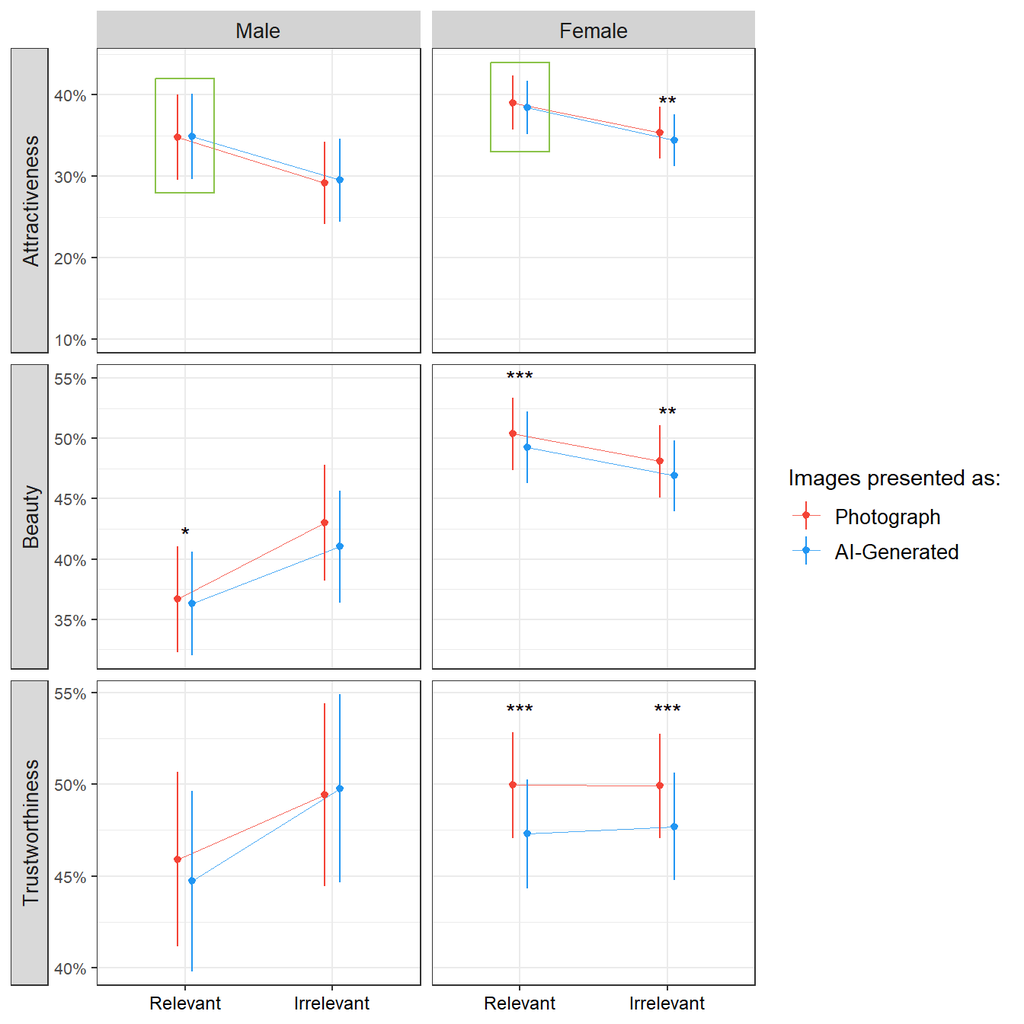

```r
pred_attr <- modelbased::estimate_means(m_attractiveness, by=c("Gender", "Relevance", "Condition")) |>
  as.data.frame() |>
  mutate(Outcome="Attractiveness")

pred_beauty <- modelbased::estimate_means(m_beauty, by=c("Gender", "Relevance", "Condition")) |>
  as.data.frame() |>
  mutate(Outcome="Beauty")

pred_trust <- modelbased::estimate_means(m_trustworthiness, by=c("Gender", "Relevance", "Condition")) |>
  as.data.frame() |>
  mutate(Outcome="Trustworthiness")

pred4 <- rbind(pred_attr, pred_beauty, pred_trust)

stars1 <- data.frame(
  label = c("**", "**", "*", "***", "***", "***"),
  Gender = factor(c("Female", "Female", "Male", "Female", "Female", "Female"), levels = c("Male", "Female")),
  Relevance = c("Irrelevant", "Relevant", "Irrelevant", "Relevant", "Relevant", "Irrelevant"),
  Outcome = c("Attractiveness", "Beauty", "Beauty", "Beauty", "Trustworthiness", "Trustworthiness"),
  y = c(0.39, 0.52, 0.42, 0.55, 0.54, 0.54),
  x = c(2.0, 2, 1.0, 1, 1, 2))


p7 <- pred4 |>
  ggplot(aes(x=Relevance, y=Proportion)) +
  # geom_hline(yintercept=0, color="darkgrey") +
  geom_line(aes(group=Condition, color=Condition), position = position_dodge(width=0.2), alpha=0.8, linewidth=0.2) +
  geom_pointrange(aes(ymin =CI_low, ymax=CI_high, color=Condition), position = position_dodge(width=0.2), size=0.2) +
  facet_grid(Outcome~Gender, switch="y", scales="free") +
  scale_y_continuous(labels=scales::percent) +
  scale_color_manual(values=c("AI-Generated"="#2196F3", "Photograph"="#F44336")) +
  geom_text(data = stars1,aes(x = x, y = y, label = label),inherit.aes = FALSE,size = 4
  ) +
  geom_rect(data=data.frame(Gender=as.factor("Male"), Proportion=0.1,  Outcome="Attractiveness", Relevance="Relevant"),
            aes(xmin=0.8, xmax=1.2, ymin=0.28, ymax=0.42), color="#8BC34A", alpha=0) +
  geom_rect(data=data.frame(Gender=as.factor("Female"), Proportion=0.1,  Outcome="Attractiveness", Relevance="Relevant"),
            aes(xmin=0.8, xmax=1.2, ymin=0.33, ymax=0.44), color="#8BC34A", alpha=0) +
  # coord_cartesian(ylim=c(0.15, 0.6)) +
  theme_bw() +
  theme(axis.title.y = element_blank(),
        axis.title.x = element_blank(),
        axis.text.y = element_text(size = 8),
        strip.placement = "outside",
        strip.background.x = element_rect(fill=c("lightgrey", "blue"), color=NA),
        strip.text.x = element_text(size = 10),
        strip.text.y = element_text(size = 10),
        axis.text.x = element_text(size=9, color="black"),
        legend.text = element_text(size = 10),
        legend.position = ) +
  labs(color="Images presented as:")

p7
```

```r
ggsave("figures/figure1.png", p7, width=8, height=8, dpi=300)
```

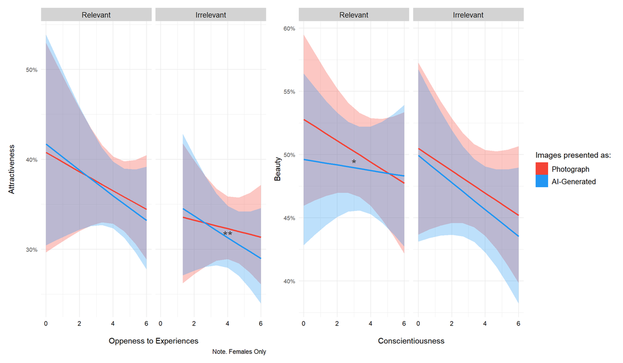

```r
p8 <- patchwork::wrap_plots(p1|p2, guides="collect")
p8
```

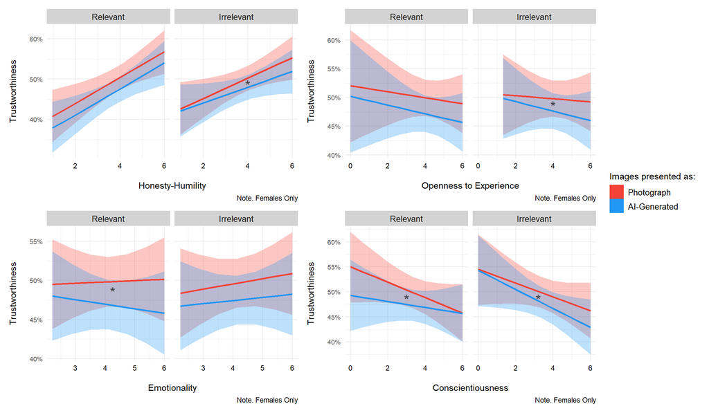

```r
p9 <- patchwork::wrap_plots((p3|p4)/(p5|p6), guides="collect")
ggsave("figures/figure3.png", p9, width=10, height=10, dpi=300)
p9
```